# Projekt: Value at Risk

- Show All Code
- Hide All Code
- View Source

Author

Mikołaj Ziółkowski

Published

January 29, 2025

# 1 Wstęp

## 1.1 Dane

**Show and hide code**

```r
dane = read.csv("C:/Users/mikol/OneDrive/Desktop/ryzyko/amzn_us_d_2002.csv")
log_returns <- diff(log(dane$Zamkniecie)) # logarytmiczne stopy zwrotu
log_returns_strata <- -diff(log(dane$Zamkniecie)) # strata
dane$Data=as.Date(dane$Data)
window_size <- 500
alpha <- 0.99
dates <- dane$Data[(window_size + 1):length(dane$Data)]
```

Dane pochodzą ze strony stooq.pl , są to dane dziennych notowań giełdowych spółki Amazon.com Inc (AMZN.US) z zakresu od 2002-01-02 do 2024-12-31. Dane zawierają 6 zmiennych: Data, Otwarcie, Najwyższy, Najniższy, Zamnknięcie, Wolumen , oraz 5786 obserwacji.  
Celem pracy jest wyznaczenie ciągu wartości 99% VaR i 99% ES z wykorzystaniem: - metody historycznej - metody historycznej z wagami - metody EWMA  
Przyjęto 500-dniowe okno danych hitorycznych, obliczono logarytmiczne stopy zwrotu oraz stratę, która powstała w wyniku przemnożenia logarytmicznych stóp zwrotu przez -1.

## 1.2 Statystyki opisowe

**Show and hide code**

```r
desc_Zamkniecie <- describe(dane$Zamkniecie)
desc_LogReturns <- describe(log_returns)

summary_stats <- data.frame(
  Statystyka = c("Średnia", "Odchylenie standardowe", "Min", "Max", "Mediana", "Skośność", "Kurtoza"),
  Zamkniecie = round(c(desc_Zamkniecie$mean, desc_Zamkniecie$sd, desc_Zamkniecie$min, desc_Zamkniecie$max,
                        desc_Zamkniecie$median, desc_Zamkniecie$skew, desc_Zamkniecie$kurtosis), 4),
  Log_Returns = round(c(desc_LogReturns$mean, desc_LogReturns$sd, desc_LogReturns$min, desc_LogReturns$max,
                         desc_LogReturns$median, desc_LogReturns$skew, desc_LogReturns$kurtosis), 4)
)

knitr::kable(
  summary_stats,
  col.names = c("Statystyka", "Zamknięcie", "Logarytmiczne Stopy Zwrotu"),
  caption = "Tabela: Statystyki opisowe dla Zamknięcia i Logarytmicznych Stóp Zwrotu",
  align = "c",
  booktabs = TRUE
) %>%
  kable_styling(latex_options = "hold_position", bootstrap_options = "striped") %>%
  row_spec(0, bold = TRUE) %>%
  column_spec(1, width = "4cm") %>%
  column_spec(2:3, width = "3cm")
```

Tabela: Statystyki opisowe dla Zamknięcia i Logarytmicznych Stóp Zwrotu

| Statystyka | Zamknięcie | Logarytmiczne Stopy Zwrotu |
| --- | --- | --- |
| Średnia | 47.4670 | 0.0010 |
| Odchylenie standardowe | 59.2952 | 0.0254 |
| Min | 0.4565 | -0.2462 |
| Max | 232.9300 | 0.2386 |
| Mediana | 14.1458 | 0.0006 |
| Skośność | 1.1557 | 0.3208 |
| Kurtoza | -0.0478 | 11.2132 |

**Wnioski**  
*Zamknięcie*  
1) Cena zamknięcia akcji średnio wynosiła 47.47 USD.  
2) Wysoka zmienność, co wskazuje na duże wahania cen.  
3) Lekko dodatnia skośność, co oznacza, że występują wartości odstające.  
4) Kurtoza prawie zerowa, co oznacza, że rozkład jest zbliżony do normalnego.  
Logarytmiczne stopy zwrotu  
1) Średnia bliska zeru, co sugeruje niewielki przeciętny dziennych wzrost wartości.  
2) Niewielka zmienność.  
3) Mediana logarytmicznych stóp zwrotu jest bliska zeru, co oznacza, że dla połowy dni zmiana ceny była nieznaczna.  
4) Bardzo wysoka kurtoza, co wskazuje na obecność wielu ekstremalnych wartości.

### 1.2.1 Wykres wycen (zamnkniecia)

**Show and hide code**

[figure not shown]

```r
# Wykres wyceny
ggplot(dane, aes(x = as.Date(Data), y = Zamkniecie)) +
  geom_line(color = "blue") +
  labs(x = "Data", y = "Cena zamknięcia", title = "Wycena akcji Apple (AAPL)") +
  scale_x_date(breaks = seq(as.Date("2002-01-02"), as.Date("2024-12-31"), by = "year"),
               labels = format(seq(as.Date("2002-01-02"), as.Date("2024-12-31"), by = "year"), "%Y")) +
  theme(axis.text.x = element_text(angle = 45, hjust = 1))
```

Na podstawie wykresu wycen można zauważyć, iż znaczący wzrost cen zamknięcia rozpoczyna się w okolicach 2016 roku. Może to być spowodowane kilkoma czynnikami, np: Amazon Web Services staje się głównum źródłem zysków,Amazon w 2015 staje się liderem e-commerce w USA, rozpoczęcie inwestycji w AI, m.in: Alexa i Amazon Echo.

### 1.2.2 Wykres logarytmicznych stóp zwrotu

**Show and hide code**

[figure not shown]

```r
dane_log_returns <- data.frame(Data = dane$Data[2:length(dane$Data)], LogReturns = log_returns)
ggplot(dane_log_returns, aes(x = as.Date(Data), y = LogReturns)) +
  geom_line(color = "red") +
  labs(x = "Data", y = "Logarytmiczne stopy zwrotu", title = "Logarytmiczne stopy zwrotu Apple (AAPL)") +
  scale_x_date(breaks = seq(as.Date("2002-01-02"), as.Date("2024-12-31"), by = "year"),
               labels = format(seq(as.Date("2002-01-02"), as.Date("2024-12-31"), by = "year"), "%Y")) +
  theme(axis.text.x = element_text(angle = 45, hjust = 1))
```

Warotść oczekiwana jest bliska zero. Wartości zgromadzone wokół średniej.

# 2 VaR

## 2.1 Metoda historyczna

**Show and hide code**

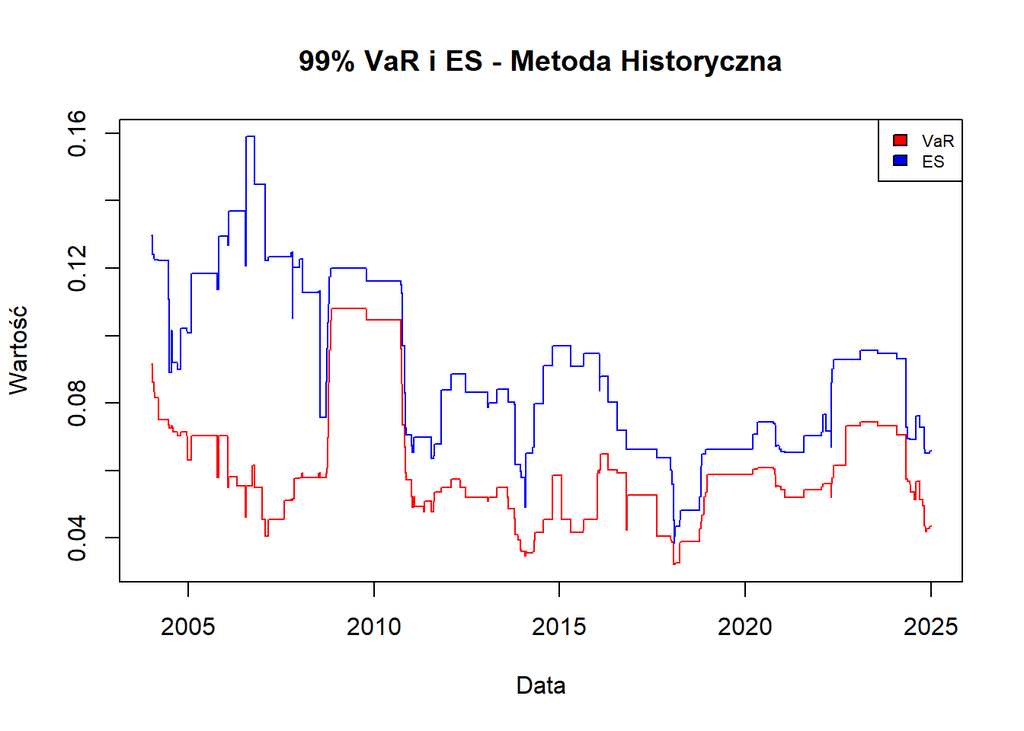

```r
compute_VaR_ES <- function(returns_window, alpha) {
  VaR <- quantile(returns_window, alpha)
  ES <- mean(returns_window[returns_window > VaR])
  return(list(VaR = VaR, ES = ES))
}

VaR_values <- numeric()
ES_values <- numeric()

# Obliczenie VaR i ES dla okna
for (i in 1:(length(log_returns_strata) - window_size + 1)) {
  window <- log_returns_strata[i:(i + window_size - 1)]
  res <- compute_VaR_ES(window, alpha)
  VaR_values <- c(VaR_values, res$VaR)
  ES_values <- c(ES_values, res$ES)
}

plot(as.Date(dates), VaR_values, type = "l", col = "red",
     xlab = "Data", ylab = "Wartość", main = "99% VaR i ES - Metoda Historyczna",
     ylim = range(VaR_values, ES_values))
lines(as.Date(dates), ES_values, col = "blue")
legend("topright", legend=c("VaR", "ES"), fill=c("red", "blue"), cex=0.7)
```

W początkowych lata widać stopniowy wzrost ryzyka, po czym następuje szybki spadek oraz zaraz gwałtowny wzrost ES, może to być związane z kryzysem finansowym w latach 2008/2009. Od 2020 skok wartości ,spowodowany najprawdopodobniej pandemią COVID-19. W latach 2023-24 stopniowy spadek ryzyka. Jednak wyniki w tej metodzie dają równe prawdopodobieństwa oraz nie biorą pod uwagę heteroskedastyczności.

## 2.2 Metoda historyczna z wagami

Można powiedzieć, iż metoda historyczna z wagami to ulepszona wersja metody historycznej, która przydziela wagi każdemu scenariuszowi. Dzięki temu lepiej uwzględnia zmieniającą się dynamikę rynku.

**Show and hide code**

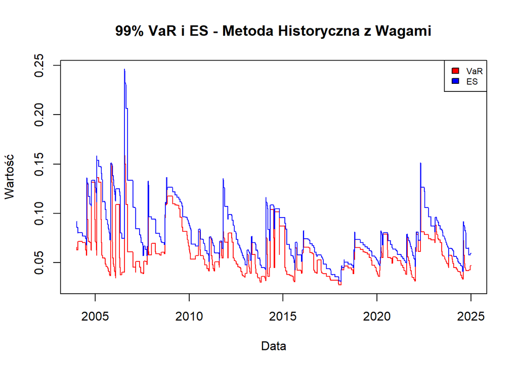

```r
compute_weighted_VaR_ES <- function(returns_window, alpha) {
  n <- length(returns_window)
  weights <- (alpha^(n:1 - 1) * (1 - alpha)) / (1 - alpha^n)#wagi
  sorted_returns <- sort(returns_window)# Sortowanie stóp zwrotu
  sorted_weights <- weights[order(returns_window)]# Przypisanie wag do posortowanych stóp zwrotu
  cumulative_weights <- cumsum(sorted_weights)# Obliczenie skumulowanych wag
  # indeksu VaR (pierwsza wartość, gdzie skumulowana waga >= alpha)
  VaR_index <- which(cumulative_weights >= alpha)[1]
  VaR <- sorted_returns[VaR_index]
  #ES
  ES <- sum(sorted_returns[VaR_index:length(sorted_returns)] *
              sorted_weights[VaR_index:length(sorted_weights)]) /
    sum(sorted_weights[VaR_index:length(sorted_weights)])

  return(list(VaR = VaR, ES = ES))
}

weighted_VaR_values <- numeric()
weighted_ES_values <- numeric()

for (i in 1:(length(log_returns_strata) - window_size + 1)) {
  window <- log_returns_strata[i:(i + window_size - 1)]
  res <- compute_weighted_VaR_ES(window, alpha)
  weighted_VaR_values <- c(weighted_VaR_values, res$VaR)
  weighted_ES_values <- c(weighted_ES_values, res$ES)
}

plot(as.Date(dates), weighted_VaR_values, type = "l", col = "red", lty = 1,
     xlab = "Data", ylab = "Wartość", main = "99% VaR i ES - Metoda Historyczna z Wagami",
     ylim = range(weighted_VaR_values, weighted_ES_values))
lines(as.Date(dates), weighted_ES_values, col = "blue", lty = 1)
legend("topright", legend=c("VaR", "ES"), fill=c("red", "blue"), cex=0.7)
```

## 2.3 Metoda EWMA

Metoda EWMA (Exponentially Weighted Moving Average) jest techniką stosowaną do modelowania zmienności finansowej, w której ostatnie obserwacje mają większą wagę niż starsze dane. Pozwala to na szybkie reagowanie na zmiany rynkowe. Metoda ta odrzuca założenie o homoskedastyczności strat.

**Show and hide code**

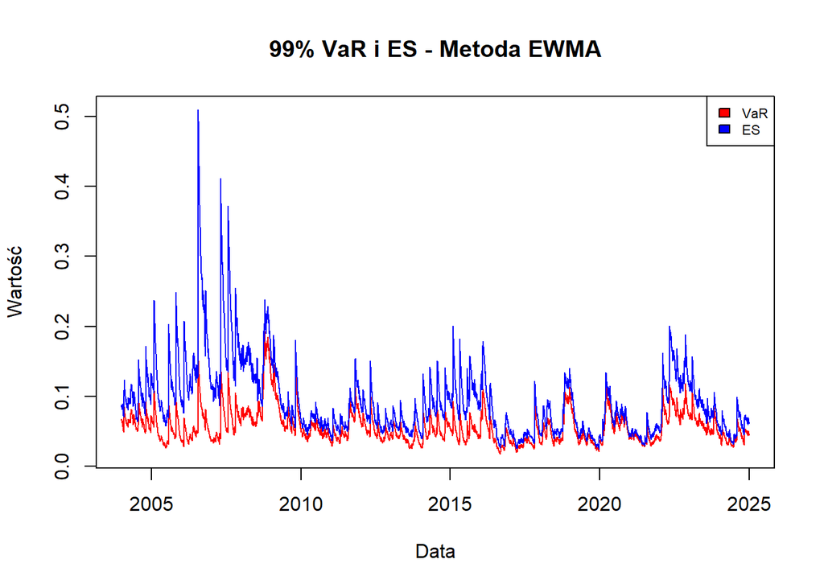

```r
# Funkcja do obliczania zmienności EWMA
ewma_volatility <- function(returns, lambda) {
  n <- length(returns)
  sigma_squared <- numeric(n)
  sigma_squared[1] <- var(returns)
  for (t in 2:n) {
    sigma_squared[t] <- lambda * sigma_squared[t - 1] + (1 - lambda) * returns[t - 1]^2
  }
  return(sqrt(sigma_squared))
}

lambda <- 0.94  # Współczynnik wygładzania w modelu EWMA

# Obliczenie zmienności EWMA dla całego szeregu
zmewma <- ewma_volatility(log_returns_strata, lambda)

ewma_VaR_values <- numeric(length(log_returns_strata) - window_size + 1)
ewma_ES_values <- numeric(length(log_returns_strata) - window_size + 1)

for (i in 1:(length(log_returns_strata) - window_size + 1)) {
  window <- log_returns_strata[i:(i + window_size - 1)]

  # Skalowanie zwrotów zgodnie z metodą EWMA
  scenariuszEwma <- window * zmewma[i + window_size - 1] / zmewma[i:(i + window_size - 1)]

  VaR_scaled <- quantile(scenariuszEwma, alpha)
  ES_scaled <- mean(scenariuszEwma[scenariuszEwma > VaR_scaled])

  ewma_VaR_values[i] <- VaR_scaled
  ewma_ES_values[i] <- ES_scaled
}

plot(as.Date(dates), ewma_VaR_values, type = "l", col = "red", lty = 1,
     xlab = "Data", ylab = "Wartość", main = "99% VaR i ES - Metoda EWMA",
     ylim = range(ewma_VaR_values, ewma_ES_values))
lines(as.Date(dates), ewma_ES_values, col = "blue", lty = 1)
legend("topright", legend = c("VaR", "ES"), fill = c("red", "blue"), cex = 0.7)
```

W tej metodzie można zauważyć bardziej reagujące zmiany. W okolicach 2015 roku widać zwiększone ryzyko, może być to wynik kryzysu na chińskim rynku akcji. Natomiast podwyższona wartość w okolicach 2020 roku wynika z pandemii COVID19. W latach 2022/23 również widać wzrost ryzyka, co może być wynikiem inflacji oraz spadku wycen spółek technologicnzych. Warto zauważyć,iż od 2023 roku zmienność Amazon spada, co może wskazywać na względną stabilizacje.

# 3 Testy Wsteczne

Testy są obliczane dla każdego okna oddzielnie, a wyniki są przedstawiane w tabeli.

## 3.1 Test kupca

Hipotezy:  
- H0 : VaR jest dobrze wyliczony - H1 : VaR jest źle obliczony

**Show and hide code**

```r
kupiec_test <- function(VaR_hits, alpha) {
  n <- length(VaR_hits)
  x <- sum(VaR_hits)
  pi_hat <- x / n
  L0 <- x * log(alpha) + (n - x) * log(1 - alpha)
  L1 <- x * log(pi_hat) + (n - x) * log(1 - pi_hat)
  LR_uc <- -2 * (L0 - L1)
  p_value <- 1 - pchisq(LR_uc, df = 1)
  list(exceptions = x, LR_uc = LR_uc, p_value = p_value)
}

metody <- c("Historyczna", "Hist. z wagami", "EWMA")
tabela_test_kupiec <- data.frame(Metoda = metody, Odrzucone = 0, Nieodrzucone = 0)

oblicz_test <- function(VaR_values) {
  temp <- sapply(1:(length(log_returns_strata) - window_size + 1), function(i) {
    VaR_hit <- ifelse(log_returns_strata[i:(i + window_size - 1)] > VaR_values[i], 1, 0)
    ifelse(kupiec_test(VaR_hit, 0.01)$p_value < 0.05, 1, 0)
  })
  sum(temp, na.rm = TRUE)
}

tabela_test_kupiec$Odrzucone[1] <- oblicz_test(VaR_values)
tabela_test_kupiec$Nieodrzucone[1] <- length(log_returns_strata) - 499 - tabela_test_kupiec$Odrzucone[1]

tabela_test_kupiec$Odrzucone[2] <- oblicz_test(weighted_VaR_values)
tabela_test_kupiec$Nieodrzucone[2] <- length(log_returns_strata) - 499 - tabela_test_kupiec$Odrzucone[2]

tabela_test_kupiec$Odrzucone[3] <- oblicz_test(ewma_VaR_values)
tabela_test_kupiec$Nieodrzucone[3] <- length(log_returns_strata) - 499 - tabela_test_kupiec$Odrzucone[3]

kable(tabela_test_kupiec, format = "html") %>%
  kable_styling(full_width = FALSE, bootstrap_options = c("striped", "hover"))
```

| Metoda | Odrzucone | Nieodrzucone |
| --- | --- | --- |
| Historyczna | 0 | 5286 |
| Hist. z wagami | 1854 | 3432 |
| EWMA | 2486 | 2800 |

## 3.2 Test świateł

Test świateł (Traffic Light Test) to metoda oceny jakości modelu VaR. Polega on na klasyfikacji liczby przekroczeń VaR do trzech stref (zielonej, żółtej i czerwonej), gdzie zielona oznacza dobrą jakość modelu, żółta sygnalizuje potencjalne problemy, a czerwona wskazuje na istotne niedoszacowanie ryzyka.

**Show and hide code**

```r
tabela_test_swiatla = data.frame("Zielone" = rep(1,3),
                                 "Żółte" = rep(1,3),
                                 "Czerwone" = rep(1,3),
                                 row.names = c("Historyczna", "Hist. z wagami",
                                               "EWMA"))

test_swiatel <- function(VaR_hits) {

  n <- length(VaR_hits)
  exceptions <- sum(VaR_hits)

  green_limit <- qbinom(c(0.001,0.95), n, 1 - alpha)
  yellow_limit <- qbinom(c(0.95,0.999), n, 1 - alpha)

  if (exceptions <= green_limit[2]) {
    zone <- "Green"
  } else if (exceptions <= yellow_limit[2]) {
    zone <- "Yellow"
  } else {
    zone <- "Red"
  }

  list(
    exceptions = exceptions,
    green_limit = green_limit,
    zone = zone
  )
}

#metoda historyczna
temp_hist=c()
for(i in 1:(length(log_returns_strata) - window_size +1)){
  Var_hit_hist=ifelse(log_returns_strata[i:(i+499)] > VaR_values[i], 1, 0)
  temp_hist[i]=ifelse(test_swiatel(Var_hit_hist)$zone == "Green", "Zielone",
                      ifelse(test_swiatel(Var_hit_hist)$zone == "Yellow",
                             "Żółte", "Czerwone"))
}

tab_hist = table(temp_hist)
tabela_test_swiatla[1,1]=ifelse(is.na(tab_hist["Zielone"]), 0, tab_hist["Zielone"])
tabela_test_swiatla[1,2]=ifelse(is.na(tab_hist["Żółte"]), 0, tab_hist["Żółte"])
tabela_test_swiatla[1,3]=ifelse(is.na(tab_hist["Czerwone"]), 0, tab_hist["Czerwone"])



#metoda hist z wagami
temp_wagi=c()
for(i in 1:(length(log_returns_strata) - window_size+1)){
  Var_hit_wagi=ifelse(log_returns_strata[i:(i+499)] > weighted_VaR_values[i], 1, 0)
  temp_wagi[i]=ifelse(test_swiatel(Var_hit_wagi)$zone == "Green", "Zielone",
                      ifelse(test_swiatel(Var_hit_wagi)$zone == "Yellow",
                             "Żółte", "Czerwone"))
}
tab_wagi = table(temp_wagi)
tabela_test_swiatla[2,1]=ifelse(is.na(tab_wagi["Zielone"]), 0, tab_wagi["Zielone"])
tabela_test_swiatla[2,2]=ifelse(is.na(tab_wagi["Żółte"]), 0, tab_wagi["Żółte"])
tabela_test_swiatla[2,3]=ifelse(is.na(tab_wagi["Czerwone"]), 0, tab_wagi["Czerwone"])

# metoda ewma
temp_ewma=c()
for(i in 1:(length(log_returns_strata) - window_size+1)){
  Var_hit_ewma=ifelse(log_returns_strata[i:(i+499)] > ewma_VaR_values[i], 1, 0)
  temp_ewma[i]=ifelse(test_swiatel(Var_hit_ewma)$zone == "Green", "Zielone",
                      ifelse(test_swiatel(Var_hit_ewma)$zone == "Yellow",
                             "Żółte", "Czerwone"))
}
tab_ewma = table(temp_ewma)
tabela_test_swiatla[3,1]=ifelse(is.na(tab_ewma["Zielone"]), 0, tab_ewma["Zielone"])
tabela_test_swiatla[3,2]=ifelse(is.na(tab_ewma["Żółte"]), 0, tab_ewma["Żółte"])
tabela_test_swiatla[3,3]=ifelse(is.na(tab_ewma["Czerwone"]), 0, tab_ewma["Czerwone"])

tabela_test_swiatla %>%
  kbl(col.names = c("Metoda", "Zielone", "Żółte", "Czerwone"), format = "html") %>%
  kable_styling(full_width = FALSE, bootstrap_options = c("striped", "hover")) %>%
  column_spec(2, color = "green") %>%
  column_spec(3, color = "orange") %>%
  column_spec(4, color = "red")
```

| Metoda | Zielone | Żółte | Czerwone |
| --- | --- | --- | --- |
| Historyczna | 5286 | 0 | 0 |
| Hist. z wagami | 3784 | 670 | 832 |
| EWMA | 3054 | 627 | 1605 |

**WNIOSKI**  
We wszystkich trzech metodach większość przypadków znajduje się w strefie zielonej. Dla metody historycznej wszystkie przypadki znajdują się w strefie zielonej. Metoda hist. z wagami oraz metoda EWMA znajdują się częsciowo w strefie żółtej i czerwonej. Jednak w przypadku metody EWMA dość znaczna liczba przypadków jest w strefie czerwonej, co może sugerować niedoszacowanie ryzyka.

## 3.3 Test Christoffersena

Test Christoffersona bada niezależność sekwencji przekroczeń wartości zagrożonej (VaR) poprzez analizę przejść między dniami z i bez przekroczeń. Ocena skupia się na autokorelacji w występowaniu strat, co pozwala sprawdzić, czy model VaR poprawnie odzwierciedla zmienność rynku w czasie.  
Hipotezy:  
H0: Przekroczenia VaR są niezależne w czasie  
H1: Przekroczenia VaR nie są niezależne w czasie

**Show and hide code**

```r
tabela_test_christoff = data.frame("odrzucone" = rep(1,3),
                            "nieodrzucone" = rep(1,3),
                            row.names = c("Historyczna", "Hist. z wagami",
                                          "EWMA"))

test_christoffersona <- function(VaR_hits) {
  # Budowanie macierzy przejść
  transitions <- table(factor(VaR_hits[-length(VaR_hits)], levels = c(0, 1)),
                       factor(VaR_hits[-1], levels = c(0, 1)))
  # Liczby przejść
  n00 <- transitions[1, 1]
  n01 <- transitions[1, 2]
  n10 <- transitions[2, 1]
  n11 <- transitions[2, 2]

  # Prawdopodobieństwa przejść
  p0 <- ifelse(n00 + n01 > 0, n01 / (n00 + n01), 0)
  p1 <- ifelse(n10 + n11 > 0, n11 / (n10 + n11), 0)
  pi_hat <- ifelse(n00 + n01 + n10 + n11 > 0, (n01 + n11) / (n00 + n01 + n10 + n11), 0)

  # Zmiana dla przypadków równych zero
  p0 <- max(p0, 0.000001)
  p1 <- max(p1, 0.000001)
  pi_hat <- max(pi_hat, 0.000001)

  # Statystyka log-likelihood ratio
  L_ind <- n00 * log(1 - p0) + n01 * log(p0) +
    n10 * log(1 - p1) + n11 * log(p1)
  L_un <- (n00 + n10) * log(1 - pi_hat) + (n01 + n11) * log(pi_hat)
  LR_ind <- -2 * (L_un - L_ind)

  p_value <- 1 - pchisq(LR_ind, df = 1)

  list(
    LR_ind = LR_ind,
    p_value = p_value
  )
}

#metoda historyczna
temp_hist=c()
for(i in 1:(length(log_returns_strata) - window_size+1)){
  Var_hit_hist=ifelse(log_returns_strata[i:(i+499)] > VaR_values[i], 1, 0)
  temp_hist[i]=ifelse(test_christoffersona(Var_hit_hist)$p_value < 0.05, 1, 0)
}

tabela_test_christoff[1,1]=sum(temp_hist, na.rm=T)
tabela_test_christoff[1,2]=length(log_returns_strata)-499 - sum(temp_hist, na.rm=T)


#metoda hist z wagami
temp_wagi=c()
for(i in 1:(length(log_returns_strata) - window_size+1)){
  Var_hit_wagi=ifelse(log_returns_strata[i:(i+499)] > weighted_VaR_values[i], 1, 0)
  temp_wagi[i]=ifelse(test_christoffersona(Var_hit_wagi)$p_value < 0.05, 1, 0)
}
tabela_test_christoff[2,1]=sum(temp_wagi)
tabela_test_christoff[2,2]=length(log_returns_strata)-499 - sum(temp_wagi)

#metoda ewma
temp_ewma=c()
for(i in 1:(length(log_returns_strata) - window_size+1)){
  Var_hit_ewma=ifelse(log_returns_strata[i:(i+499)] > ewma_VaR_values[i], 1, 0)
  temp_ewma[i]=ifelse(test_christoffersona(Var_hit_ewma)$p_value < 0.05, 1, 0)
}
tabela_test_christoff[3,1]=sum(temp_ewma, na.rm=T)
tabela_test_christoff[3,2]=length(log_returns_strata)-499 - sum(temp_ewma, na.rm=T)

tabela_test_christoff <- data.frame(
  Metoda = c("Historyczna", "Hist. z wagami", "EWMA"),
  Odrzucone = c(sum(temp_hist, na.rm = TRUE),
                sum(temp_wagi, na.rm = TRUE),
                sum(temp_ewma, na.rm = TRUE)),
  Nieodrzucone = c(length(log_returns_strata) - 499 - sum(temp_hist, na.rm = TRUE),
                   length(log_returns_strata) - 499 - sum(temp_wagi, na.rm = TRUE),
                   length(log_returns_strata) - 499 - sum(temp_ewma, na.rm = TRUE))
)

kable(tabela_test_christoff, format = "html", col.names = c("Metoda", "Odrzucone", "Nieodrzucone")) %>%
  kable_styling(full_width = FALSE, bootstrap_options = c("striped", "hover", "condensed")) %>%
  column_spec(1, bold = TRUE) %>%
  column_spec(2:3, width = "5em")
```

| Metoda | Odrzucone | Nieodrzucone |
| --- | --- | --- |
| Historyczna | 665 | 4621 |
| Hist. z wagami | 532 | 4754 |
| EWMA | 436 | 4850 |

Test wskazuje, iż w większości przypadków przkroczenia są nieżależne w czasie dla każdej z metod. Metoda EWMA osiągnęła najlepszy wyniki, co sugeruje, że lepiej uchwyciła dynamikę ryzyka w czasie.

# 4 Podsumowanie

Ranking według testów,od najlepszego do najsłabszego wyniku(najlepszy=największa liczba testów nieodrzuconych)  
Test Kupca:  
1. historyczna  
2. historyczna z wagami  
3. EWMA  
Test Świateł:  
1. historyczna  
2. historyczna z wagami  
3. EWMA  
Test Christoffersena:  
1. EWMA  
2. hisoryczna z wagami  
3. historyczna

Analizując powyższe wyniki, można zauważyć, że metoda historyczna uzyskała najlepsze wyniki w testach Kupca i Świateł. Oznacza to, że dobrze przewiduje ryzyko w długim okresie i charakteryzuje się wysoką stabilnością. Jednak jej największą wadą jest brak elastyczności – traktuje wszystkie dane historyczne z taką samą wagą, co może prowadzić do niedoszacowania ryzyka w dynamicznie zmieniających się warunkach rynkowych. Z kolei metoda EWMA uzyskała najlepszy wynik w teście Christoffersena, co sugeruje, że dobrze radzi sobie z dynamicznymi zmianami i adaptacją do nowych danych. Jednak w testach Kupca i Świateł wypada najsłabiej, co może wskazywać na większą niestabilność i nadmierną reakcję na krótkoterminowe wahania. Najbardziej zbalansowaną metodą wydaje się metoda historyczna z wagami. Pomimo że nie osiągnęła pierwszego miejsca w żadnym z testów, zajęła drugie miejsce we wszystkich trzech testach. Łączy stabilność metody historycznej z pewnym stopniem elastyczności, przypisując większą wagę nowszym obserwacjom. Dzięki temu lepiej oddaje rzeczywistą zmienność waloru i pozwala na bardziej precyzyjne modelowanie ryzyka.

Na podstawie analizy stwierdzam, iż najlepszą metodą do wybranych danych jest metoda historyczna z wagami, ponieważ nie traktuje wszystkich obserwacji jednakowo, co pozwala lepiej odzwierciedlać zmieniające się warunki rynkowe, również dość dobrze wypadła w przeprowadzonych testach wstecznych.